# Liver Cancer Prediction using Deep Learning

This script implements a deep learning model for liver cancer prediction, covering the following key steps:

- **Data preprocessing:** Handling missing values, data balancing, and feature scaling.
- **Model creation:** Neural network architecture design and hyperparameter tuning.
- **Training and evaluation:** Model training, performance assessment, and visualization of results.
- **Explainability analysis:** Using SHAP to interpret feature importance and model decisions.

The dataset originates from the PLCO study and is prepared to enhance the predictive capabilities of deep learning techniques.

Author: Juan Armario  
Date: 2024

# Importing libraries

```python
import numpy as np
import pandas as pd

# Plotting
import matplotlib.cm as cm
import matplotlib.pyplot as plt
import seaborn as sns

# Machine learning and preprocessing
from imblearn.over_sampling import SMOTE
from sklearn.impute import SimpleImputer
from sklearn.metrics import classification_report, confusion_matrix
from sklearn.model_selection import train_test_split
from sklearn.preprocessing import StandardScaler

# Deep learning - TensorFlow/Keras
import shap
import tensorflow as tf
from tensorflow import keras
from tensorflow.keras import layers
from tensorflow.keras.callbacks import EarlyStopping
from tensorflow.keras.layers import BatchNormalization, Dense, Dropout
from tensorflow.keras.models import Sequential
from tensorflow.keras.optimizers import Adam

# Hyperparameter tuning
import keras_tuner as kt

## Others
import warnings
import sys
# Hide warnings
warnings.filterwarnings('ignore')

# Custom functions
sys.path.append("../0. Scripts")
import neural_networks_functions as nnf
```

# Loading data

```python
liver_cancer_dataset = pd.read_csv('../0. Data/0. Original/liver_data_mar22_d032222.csv')
etiquetas = liver_cancer_dataset.liver_cancer

df_imputed = liver_cancer_dataset.copy()

# Deleting non useful variables
data = df_imputed.drop(columns=['liver_cancer', 'liver_topography', 'plco_id', 'build'])
```

```python
feature_names = data.columns.tolist()
```

# Imputation

Handling missing values is a crucial step in data preprocessing, as incomplete data can negatively impact model performance. In this section, we apply **mean imputation** to replace missing values with the average of each feature. This method ensures that no valuable information is lost while maintaining the dataset’s overall statistical properties.

By imputing missing values, we prepare the dataset for training and improve the robustness of our deep learning model.

```python
# Missing values imputation with the mean
imputer = SimpleImputer(strategy="mean")
data_imputed = pd.DataFrame(imputer.fit_transform(data), columns=data.columns)
```

# Data balancing

Class imbalance is a common challenge in medical datasets, where one class significantly outweighs the other. In this section, we address this issue using **SMOTE (Synthetic Minority Over-sampling Technique)** to generate synthetic samples for the minority class.

Balancing the dataset ensures that the model does not become biased toward the majority class, improving its ability to correctly identify cases of liver cancer. This step is essential for enhancing recall and overall predictive performance.

```python
# Split training and test set
X_train, X_test, y_train, y_test = train_test_split(data_imputed, etiquetas, test_size=0.2, random_state=42)

# Balancing classes with SMOTE
smote = SMOTE(random_state=42)
X_train_res, y_train_res = smote.fit_resample(X_train, y_train)
```

# Normalization

Feature normalization is a crucial step in preparing data for deep learning models, particularly for neural networks, where different feature scales can impact model performance.

In this section, we apply **StandardScaler,** which standardizes the dataset by removing the mean and scaling to unit variance. This ensures that all features contribute equally to the model and helps in accelerating convergence during training.

Normalization enhances the stability and efficiency of the training process, preventing features with larger ranges from dominating those with smaller ranges.

```python
scaler = StandardScaler()
X_train_norm = scaler.fit_transform(X_train_res)
X_test_norm = scaler.transform(X_test)
```

# Model creation and hyperparameters tuning

In this section, we focus on building an optimal deep learning model for liver cancer prediction. The process consists of two key steps:

1. Model Architecture Design:

We define a neural network using TensorFlow/Keras, incorporating key layers such as **BatchNormalization, Dropout, and Dense layers.** These components help stabilize training, prevent overfitting, and improve generalization.

2. Hyperparameter Tuning with Keras Tuner:

To optimize model performance, we use Keras Tuner, an automated framework that searches for the best hyperparameters. The objective function is set to maximize recall, ensuring the model effectively identifies liver cancer cases. - We explore different values for learning rate, number of neurons, dropout rates, and batch sizes. - The Hyperband algorithm is used to efficiently search for the best combination of hyperparameters.

By fine-tuning these parameters, we aim to develop a **high-performing** and robust neural network capable of accurate liver cancer classification.

```python
# Searching de hyperparameters with Keras Tuner
tuner = kt.Hyperband(
    nnf.build_model,
    objective=kt.Objective("val_recall", direction="max"),  # Specifying which metrics maximize
    max_epochs=20,
    factor=3,
    project_name="full_dataset_tuning_v1"
)

# Early stopping callback
early_stopping = EarlyStopping(
    monitor='val_loss',  # Monitoring val_loss
    patience=5,
    restore_best_weights=True
)

tuner.search(X_train_norm, y_train_res, epochs=20, callbacks=[early_stopping], validation_split=0.2, verbose=1)

# Getting the best hyperparameters founded
best_hps = tuner.get_best_hyperparameters(num_trials=1)[0]

# Building a model with the best hyperparameters
model = nnf.build_model(best_hps, X_train_norm)
```

```
Reloading Tuner from ./full_dataset_tuning_v1/tuner0.json
```

# Model Training and Evaluation

In this section, we train and evaluate the deep learning model using the best hyperparameters obtained from the tuning process. The training phase is designed to optimize model performance while preventing overfitting.

1. **Training the Model**
   - The model is trained using **cross-entropy loss** and the **Adam optimizer,** which dynamically adjusts learning rates for efficient convergence.
   - **Class weighting** is applied to address data imbalance, ensuring the model prioritizes correctly identifying liver cancer cases.
   - **Early stopping** and **learning rate reduction** callbacks are implemented to prevent overfitting and stabilize training.
2. **Model Evaluation**
   - The trained model is evaluated on the test set, where key classification metrics are computed:
     - **Recall:** Measures the model's ability to correctly identify cancer cases (most critical metric).
     - **Precision & F1-Score:** Evaluate prediction quality, balancing false positives and false negatives.
     - **Accuracy:** Provides an overall performance measure but is less relevant in imbalanced datasets.
   - **Confusion matrices and ROC-AUC scores** help visualize classification performance, highlighting strengths and areas for improvement.

By thoroughly evaluating the model, we ensure reliability and robustness in detecting liver cancer while balancing sensitivity and specificity.

```python
# Model training with callbacks
callbacks = [
    keras.callbacks.EarlyStopping(
        monitor='val_loss', patience=10, restore_best_weights=True, verbose=1
    ),
    keras.callbacks.ReduceLROnPlateau(monitor='val_loss', factor=0.2, patience=5)
]

class_weights = {0: 1, 1: 6}  # Giving more importance to the minority class
history = model.fit(X_train_norm, y_train_res, validation_split=0.2, epochs=20, class_weight=class_weights, callbacks=callbacks)
```

```
2025-02-15 17:38:35.810830: W tensorflow/tsl/platform/profile_utils/cpu_utils.cc:128] Failed to get CPU frequency: 0 Hz
```

```python
# Test model evaluation
loss, recall, precision, accuracy = model.evaluate(X_test_norm, y_test)
print(f"🔹 Model evaluation:\n - Loss: {loss:.4f}\n - Recall: {recall:.4f}\n - precision: {precision:.4f}\n - Accuracy: {accuracy:.4f}")
```

[output not shown]

```python
# Test model prediction
y_pred = (model.predict(X_test_norm) > 0.4).astype(int)
print(classification_report(y_test, y_pred))
```

```
              precision    recall  f1-score   support

           0       1.00      1.00      1.00     30932
           1       0.91      0.91      0.91        46

    accuracy                           1.00     30978
   macro avg       0.96      0.96      0.96     30978
weighted avg       1.00      1.00      1.00     30978
```

# Plotting metrics

In this section, we visualize the performance of the trained model using various plots and evaluation metrics. Visualizing the results helps interpret the model's strengths, weaknesses, and overall effectiveness in detecting liver cancer.

By analyzing these plots, we gain insights into the model's performance and areas for further improvement, ensuring its reliability in real-world liver cancer prediction.

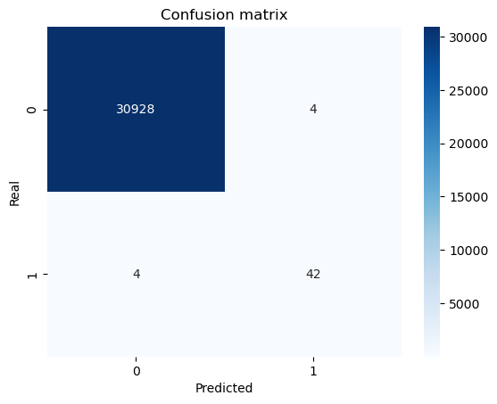

```
AUC: 0.9782018340370744
```

```python
# Confusion matrix
conf_matrix = confusion_matrix(y_test, y_pred)
sns.heatmap(conf_matrix, annot=True, fmt='d', cmap='Blues')
plt.xlabel("Predicted")
plt.ylabel("Real")
plt.title("Confusion matrix")
plt.show()

from sklearn.metrics import roc_auc_score
auc = roc_auc_score(y_test, model.predict(X_test_norm))
print("AUC:", auc)
```

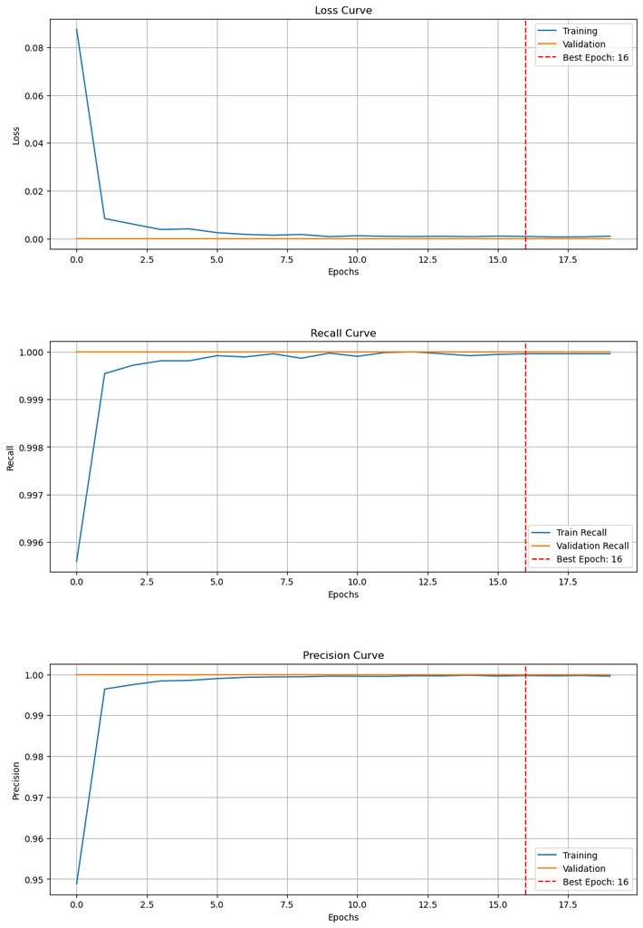

```python
nnf.plot_training_curves(history)
```

```python
#model.save("modelo_liver_cancer.h5")  # Guardar modelo
#loaded_model = keras.models.load_model("modelo_liver_cancer.h5")  # Cargarlo después
```

```python
#loaded_model = keras.models.load_model("modelo_liver_cancer.h5")
```

# SHAP CONFIGURATION

```python
shap.initjs()
```

```python
# 1️⃣ Convertir X_train_norm en un DataFrame con nombres de columna
X_train_norm_df = pd.DataFrame(X_train_norm, columns=feature_names)

# 2️⃣ Recuperar la columna "sex" antes de la normalización desde X_train_res
X_train_original_df = pd.DataFrame(X_train_res, columns=feature_names)  # data antes de normalizar
sex_original = X_train_original_df["sex"].values  # Obtener valores originales de "sex"

# 3️⃣ Crear el explicador SHAP con los data de entrenamiento normalizados
explainer = shap.Explainer(model, X_train_norm)
```

# Summary plot

```python
# 4️⃣ Seleccionar un subconjunto de X_train_norm para SHAP
num_samples = 1000  # Se aumenta para mejor representación
X_train_subset = X_train_norm_df[:num_samples]  # Subconjunto de X_train_norm después de normalizar
shap_values = explainer(X_train_subset)  # Explicamos solo estas muestras
```

```python
shap.summary_plot(shap_values, X_train_subset[:num_samples], feature_names=feature_names)
```

[output not shown]

# Beeswarm plot

```python
import matplotlib.cm as cm  # Para usar una escala de color personalizada

# 5️⃣ Crear etiquetas de sexo en formato numérico para colorización (Male=0, Female=1)
sex_labels_numeric = np.array([0 if sex_original[i] == 1 else 1 for i in range(num_samples)])

# 6️⃣ Mapear colores en una escala continua usando 'coolwarm'
cmap = cm.bwr  # Escala de color de azul a rojo
color_values = cmap(sex_labels_numeric / max(sex_labels_numeric))  # Normalizar valores de 0 a 1

# 7️⃣ Crear el Beeswarm Plot con la escala de color diferenciando sexos
plt.figure(figsize=(10, 6))
plt.title("SHAP Beeswarm - Diferenciando por Sexo con Escala de Color")
shap.plots.beeswarm(shap_values.abs, color=color_values)  # Aplicar la escala de color
plt.show()
```

[output not shown]

# Plot bars

```python
shap.plots.bar(shap_values)
```

[output not shown]

```python
# 5️⃣ Crear etiquetas de sexo basadas en los valores originales (sin normalizar)
sex_labels = np.array(["Women" if sex_original[i] == 2 else "Men" for i in range(num_samples)])

# 6️⃣ Crear cohortes en SHAP usando las etiquetas de sexo
shap_cohorts = shap_values.cohorts(sex_labels)

# 7️⃣ Graficar importancia de características agrupadas por sexo
shap.plots.bar(shap_cohorts.abs.mean(0))
```

[output not shown]

```python
# 1️⃣ Convertir X_train_norm en un DataFrame con nombres de columna
X_train_norm_df = pd.DataFrame(X_train_norm, columns=feature_names)

# 2️⃣ Recuperar la columna "sex" antes de la normalización desde X_train_res
X_train_original_df = pd.DataFrame(X_train_res, columns=feature_names)  # data antes de normalizar
sex_original = X_train_original_df["sex"].values  # Obtener valores originales de "sex"

# 3️⃣ Crear el explicador SHAP con los data de entrenamiento normalizados
explainer = shap.Explainer(model, X_train_norm)
```

```python
num_samples = 1000  # Se aumenta para mejor representación
X_train_subset = X_train_norm_df[:num_samples]  # Subconjunto de X_train_norm después de normalizar
shap_values = explainer(X_train_subset)  # Explicamos solo estas muestras
```

```python
# Verifica que 'agelevel' esté en las características
if 'agelevel' in feature_names:
    # Encuentra el índice de 'agelevel'
    feature_index = feature_names.index('agelevel')

    # Verifica la forma de shap_values.values
    print(f"Forma de shap_values.values: {shap_values.values.shape}")

    # Verifica el índice de la característica
    print(f"Índice de 'agelevel': {feature_index}")
    print(f"Número de características: {len(feature_names)}")

    # Asegúrate de que el índice esté dentro de los límites
    if feature_index < shap_values.values.shape[1]:
        # Crea el gráfico de dispersión usando .values
        shap.plots.scatter(shap_values[:, feature_index].values, color=shap_values)
    else:
        print(f"Error: El índice {feature_index} está fuera de los límites.")
else:
    print("Error: 'agelevel' no es una característica válida.")
```

[output not shown]

# Dependence plot

```python
# Gráfico de dependencia para una característica específica (ejemplo: primera característica)
shap.dependence_plot(0, shap_values.values, X_test_np, feature_names=feature_names)
```

```python
shap.dependence_plot("sex", shap_values.values, X_test_ext, feature_names=feature_names + ["liver_cancer"], interaction_index="liver_cancer")
```

# Force plot

```python
# 4️⃣ Seleccionar un subconjunto de X_train_norm para SHAP
num_samples = 1000  # Aumentamos la muestra para visualizar más predicciones
X_train_subset = X_train_norm_df[:num_samples]  # Subconjunto de X_train_norm después de normalizar
shap_values = explainer(X_train_subset)  # Explicamos solo estas muestras

# 5️⃣ Obtener los valores base y SHAP para el Force Plot
expected_value = shap_values.base_values.mean()  # Valor esperado del modelo
shap_values_data = shap_values.values  # Valores SHAP de las muestras

# 6️⃣ Crear el Force Plot para múltiples predicciones
shap.initjs()  # Habilitar visualización interactiva en Jupyter Notebook
shap.force_plot(expected_value, shap_values_data, X_train_subset, feature_names=feature_names)
```

[output not shown]